# Math 421 - Midterm

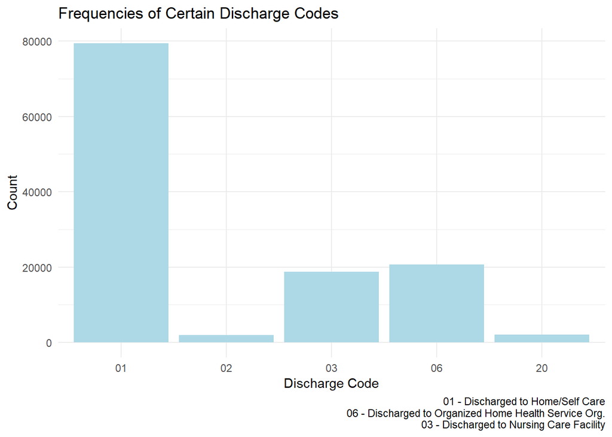

```r
top_5 <- df_wSeason %>%
  mutate(dispub92 = as.factor(dispub92)) %>%
  group_by(dispub92) %>%
  count() %>%
  arrange(-n) %>%
  head(5)

top_5 %>%
  ggplot(aes(x = dispub92, y = n)) +
  geom_bar(stat = 'identity', fill = 'lightblue') +
  labs(title = 'Frequencies of Certain Discharge Codes',
       x = 'Discharge Code',
       y = 'Count',
       caption = '01 - Discharged to Home/Self Care\n06 - Discharged to Organized Home Health Service Org.\n03 - Discharged to Nursing Care Facility') +
  theme_minimal()
```

2. Make an animation plot.

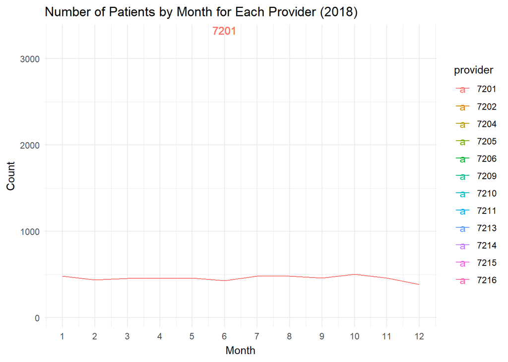

```r
library(gganimate)

df_wSeason %>%
  mutate(provider = as.factor(provider)) %>%
  filter(yoa == 18) %>%
  group_by(provider, moa) %>%
  count() %>%
  ggplot(aes(x=moa, y=n, color = provider)) +
  geom_line() +
  geom_text(aes(x = 6, y = max(n), label = provider), vjust = -0.5, hjust = 0.5, show.legend = TRUE) +
  labs(title = 'Number of Patients by Month for Each Provider (2018)',
       x = 'Month',
       y = 'Count') +
  scale_x_continuous(breaks = 1:12) +
  theme_minimal() +
  transition_states(provider, transition_length = 3, state_length = 4) +
  enter_fade() +
  exit_fade()
```

3. Write a paragraph to summarize the section and give your comments on the results.

## III. Predictive Models

Continue with the data from part I. Make sure you do not have any missing values in the data. Use the follows as the target and input variables:

*Target Variable*: Create the target variable taking value of

- `low` if the total charge of a patient (`tot`) is smaller than the median of the total charge, and
- `high` otherwise.

*Input Variables*:

- “age”,“sex”,“raceethn”,“provider”,“moa”,“mod”,“admtype”,“campus”, ‘los’

```r
library(rpart)
library(caret)
library(rattle)
```

1. Use `filter` function to filter out rows where `raceethn==''` or `admtype==''`. Make sure all the categorical variables are factor, numeric variables are numeric. Set Training : Testing Split = 10 : 90

```r
df$target <- if_else(df$tot < median(df$tot, na.rm=TRUE), 'low', 'high')
df$raceethn <- ifelse(is.na(df$raceethn), 'Unknown', df$raceethn)

df <- drop_na(df)

clean_df <- df %>%
  select(age, sex, raceethn, provider,
         moa, mod, admtype, campus, los, target) %>%
  mutate(age = as.numeric(age),
         sex = as.factor(sex),
         campus = as.factor(campus),
         provider = as.factor(provider),
         campus = as.factor(campus),
         los = as.numeric(los),
         moa = as.factor(moa),
         mod = as.factor(mod),
         target = as.factor(target)) %>%
  filter((raceethn != '') & (admtype != ''))

splitIndex <- createDataPartition(clean_df$target, p = 0.4,
                                  list = FALSE)
df_train <- clean_df[ splitIndex,]
df_test <- clean_df[-splitIndex,]
```

2. Train a decision tree using `rpart`. Plot the decision tree. Plot the variable importance ranked by the tree.

[figure not shown]

```r
tree_model <- rpart(target ~ ., data = df_train,
                    control = rpart.control(maxdepth = 5))

fancyRpartPlot(tree_model)
```

```r
tree_model$variable.importance
```

```
##         los     admtype    provider         age      campus    raceethn
## 7045.055809 2252.368560 1988.684325 1348.316533  462.141634  237.851332
##         sex
##    0.494244
```

```r
trControl <- trainControl(method = "cv", number = 5)

hyperparameters <- expand.grid(
  cp = seq(0.001, 0.1, by = 0.001)
)

class_model1 <- train(
  target ~ .,
  data = df_train,
  method = "rpart",
  trControl = trControl,
  tuneGrid = hyperparameters
)

pred1 <- predict(class_model1, df_test)

cm1 <- confusionMatrix(data = pred1, reference = df_test$target, positive = "high")

cm1$overall[1]
```

```
##  Accuracy
## 0.8338341
```

```r
class_model2 <- train(
  target ~ .,
  data = df_train,
  method = "glm",
  trControl = trControl
)

pred2 <- predict(class_model2, df_test)

cm2 <- confusionMatrix(data = pred2, reference = df_test$target, positive = "high")

cm2$overall[1]
```

```
## Accuracy
## 0.800469
```

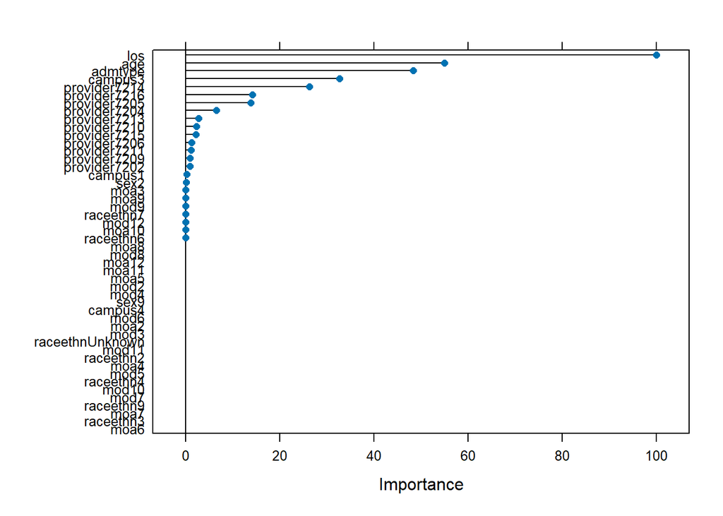

```r
plot(varImp(class_model1))
```

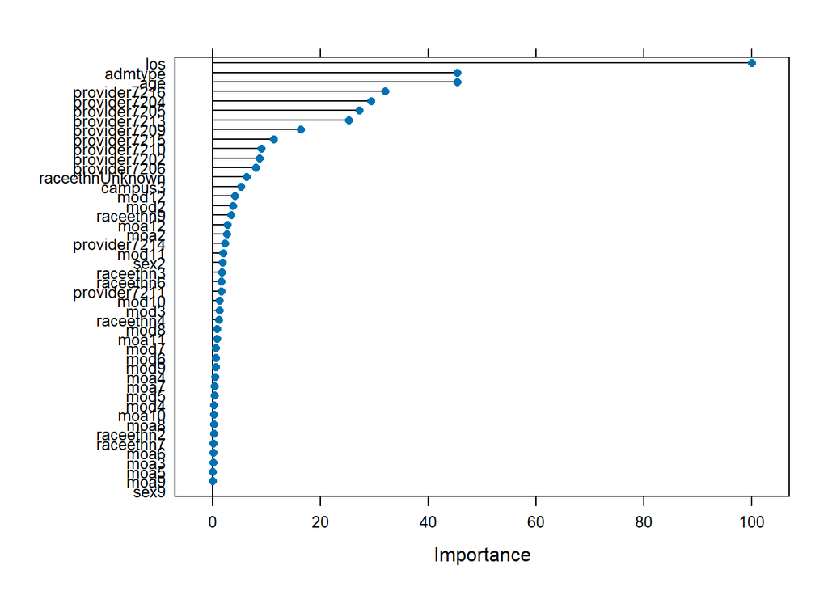

```r
plot(varImp(class_model2))
```

5. What is your final selection for the model? Test the accuracy of your final model on the test data.

```r
final_model1 <- train(
  target ~ .,
  data = df_train,
  method = "rpart",
  trControl = trControl,
  tuneGrid = hyperparameters
)

final_pred1 <- predict(final_model1, df_test)

final_cm1 <- confusionMatrix(data = final_pred1, reference = df_test$target, positive = "high")

final_cm1$overall[1]
```

```
##  Accuracy
## 0.8338341
```

6. Create another `target` variable (binary), decide the input variables and redo 1 to 5.

```r
df$target <- if_else(df$los < mean(df$los, na.rm=TRUE), 'short', 'long')

clean_df2 <- df %>%
  select(age, sex, raceethn, provider,
         moa, admtype, campus, b_wt, tot, target) %>%
  mutate(age = as.numeric(age),
         sex = as.factor(sex),
         campus = as.factor(campus),
         provider = as.factor(provider),
         moa = as.factor(moa),
         admtype = as.factor(admtype),
         b_wt = as.numeric(b_wt),
         tot = as.numeric(tot),
         target = as.factor(target)) %>%
  filter((raceethn != '') & (admtype != ''))

splitIndex <- createDataPartition(clean_df2$target, p = 0.4,
                                  list = FALSE)
df_train2 <- clean_df2[ splitIndex,]
df_test2 <- clean_df2[-splitIndex,]
```

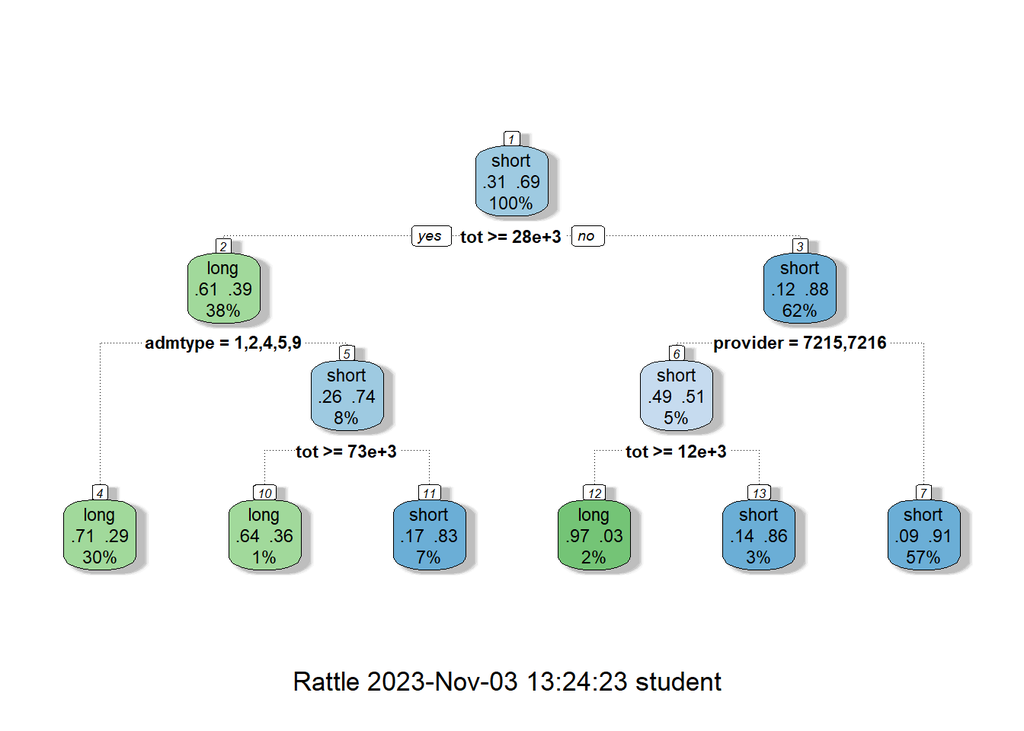

```r
tree_model2 <- rpart(target ~ ., data = df_train2,
                    control = rpart.control(maxdepth = 5))

fancyRpartPlot(tree_model2)
```

```r
trControl <- trainControl(method = "cv", number = 5)

hyperparameters <- expand.grid(
  cp = seq(0.001, 0.1, by = 0.001)
)

class_model3 <- train(
  target ~ .,
  data = df_train2,
  method = "rpart",
  trControl = trControl,
  tuneGrid = hyperparameters
)

pred3 <- predict(class_model3, df_test2)

cm3 <- confusionMatrix(data = pred3, reference = df_test2$target, positive = "long")

cm3$overall[1]
```

```
##  Accuracy
## 0.8459676
```

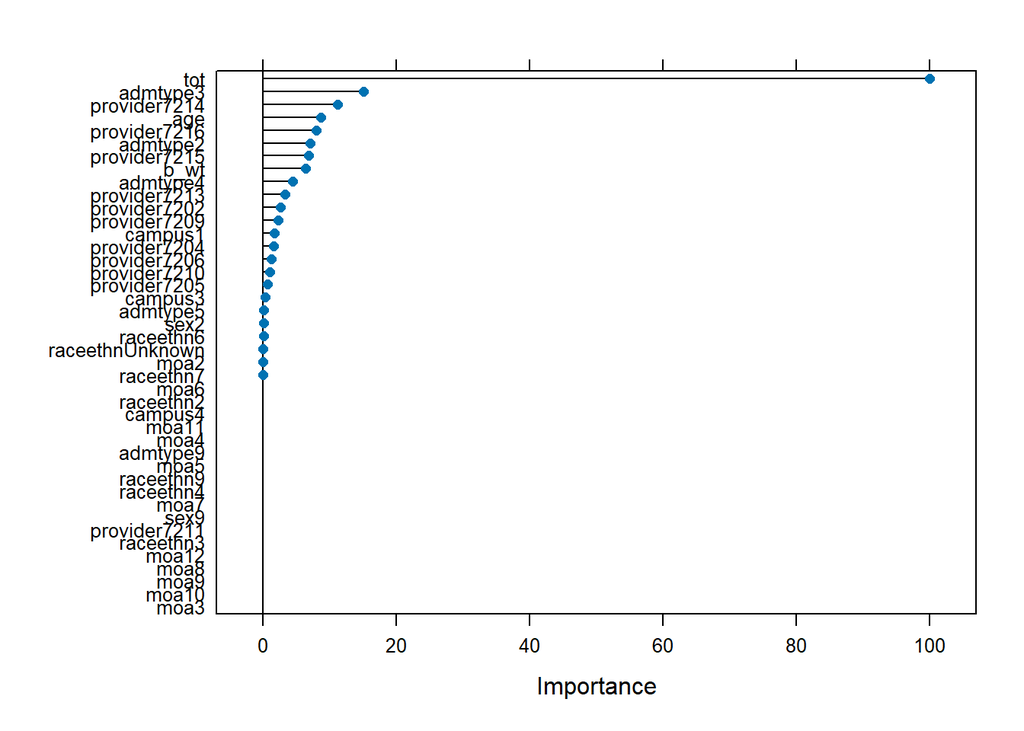

```r
plot(varImp(class_model3))
```

```r
class_model4 <- train(target ~ ., data = df_train2, method = "glm", trControl = trControl)

pred4 <- predict(class_model4, df_test2)

cm4 <- confusionMatrix(data = pred4, reference = df_test2$target, positive = "long")

cm4$overall[1]
```

```
##  Accuracy
## 0.8299191
```

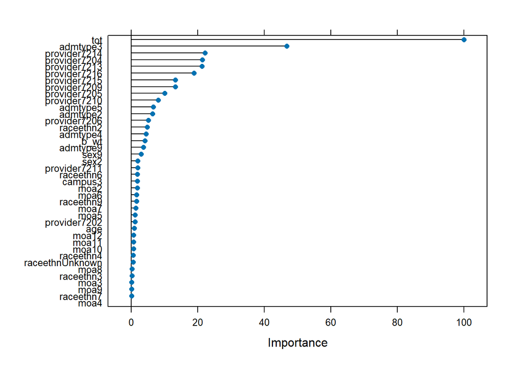

```r
plot(varImp(class_model4))
```

```r
final_model2 <- train(
  target ~ .,
  data = df_train2,
  method = "rpart",
  trControl = trControl,
  tuneGrid = hyperparameters
)

final_pred2 <- predict(final_model2, df_test2)

final_cm2 <- confusionMatrix(data = final_pred2, reference = df_test2$target, positive = "long")

final_cm2$overall[1]
```

```
##  Accuracy
## 0.8459676
```

7. Write a paragraph to summarize the section and give your comments on the results.

I think the results from our model building are promising. I was able to create two models, one predicting whether the total will be high, or low, and whether the stay of the patient will be long or short. Both final models have around an 80% accuracy, with room to improve. With that being said, I believe both models could be very much improved. I believe if I had used more features that are taken from patients initially, before their stay is over, the models could be very useful. Especially in the case of the model predicting the length of stay, this model can be useful however one feature makes it so this must be predicted after the fact. This feature is the total payment feature for this model. Since patients will not know the cost of their treatment until after the treatment, this model will not be able to accomplish as much as it could. Another way I would have like to go about this model is making it a regression model to predict the actual length of the stay, rather than a binary variable. However, the models still both predict their outcomes with high accuracy, and are very efficient all around.